# Projekt Eksploracja Danych

Michał Szulierz

czerwiec 13, 2023

## **Heart Attack Analysis & Prediction**

### **Cel Projektu**

Celem projektu jest przeprowadzenie analizy zbioru `Heart Attack Analysis & Prediction Dataset` ,stworzenie wielu modeli które będą przewidywać wystąpienie Choroby Serca u pacjenta i na końcu porównać je wszystkie i wybrać najlepszy.

### **Dane**

Zbiór danych `Heart Attack Analysis & Prediction Dataset` zawiera dane dotyczące pacjentów, którzy zostali poddani badaniom diagnostycznym związanym z chorobą serca.

1. **Wiek** - wiek pacjenta w latach
2. **Plec** - płeć pacjenta (0 - kobieta, 1 - mężczyzna)
3. **Typ_bólu** - typ bólu w klatce piersiowej (0 - typowa dławica piersiowa, 1 - nietypowa dławica piersiowa, 2 - ból niezwiązany z dławicą, 3 - typ bezobjawowy)
4. **Ciśnienie_krwi** - ciśnienie krwi w spoczynku (w mm Hg)
5. **Cholesteror** - poziom cholesterolu w surowicy (w mg/dl)
6. **Cukier** - poziom cukru we krwi na czczo (> 120 mg/dl = 1, 0 w przeciwnym razie)
7. **Wynik_EKG** - wynik elektrokardiogramu podczas spoczynku (0 - norma, 1 - odchylenie ST-T, 2 - hipertrofia lewej komory)
8. **Tętno** - maksymalne osiągnięte tętno
9. **Dławica_Piersiowa** - dławica piersiowa spowodowana wysiłkiem (0 - nie, 1 - tak)
10. **spadek_odcinka_ST** - spadek odcinka ST wywołany wysiłkiem fizycznym względem spoczynku
11. **Nachylenie** - nachylenie odcinka ST podczas wysiłku (0 - brak, 1 - nachylenie w górę, 2 - nachylenie w dół)
12. **Liczba_Naczyń** - liczba głównych naczyń krwionośnych (0-3) zabarwionych podczas fluoroskopii
13. **defekt** - rodzaj defektu (0 - brak, 1 - odwrócony, 2 - normalny, 3 - odwrócony z niedoborem)
14. **ChorobaSerca** - wartość docelowa, określająca obecność choroby serca (0-mniejsza szansa na atak serca, 1-większa szansa na atak serca)

| Wiek | Plec | Typ_bólu | Ciśnienie_krwi | Cholesterol | Cukier | Wynik_EKG | Tętno | Dławica_Piersiowa | spadek_odcinka_ST | nachylenie | Liczba_Naczyń | defekt | ChorobaSerca |
| --- | --- | --- | --- | --- | --- | --- | --- | --- | --- | --- | --- | --- | --- |
| 63 | 1 | 3 | 145 | 233 | 1 | 0 | 150 | 0 | 2.3 | 0 | 0 | 1 | 1 |
| 37 | 1 | 2 | 130 | 250 | 0 | 1 | 187 | 0 | 3.5 | 0 | 0 | 2 | 1 |
| 41 | 0 | 1 | 130 | 204 | 0 | 0 | 172 | 0 | 1.4 | 2 | 0 | 2 | 1 |
| 56 | 1 | 1 | 120 | 236 | 0 | 1 | 178 | 0 | 0.8 | 2 | 0 | 2 | 1 |
| 57 | 0 | 0 | 120 | 354 | 0 | 1 | 163 | 1 | 0.6 | 2 | 0 | 2 | 1 |
| 57 | 1 | 0 | 140 | 192 | 0 | 1 | 148 | 0 | 0.4 | 1 | 0 | 1 | 1 |
| 56 | 0 | 1 | 140 | 294 | 0 | 0 | 153 | 0 | 1.3 | 1 | 0 | 2 | 1 |
| 44 | 1 | 1 | 120 | 263 | 0 | 1 | 173 | 0 | 0.0 | 2 | 0 | 3 | 1 |
| 52 | 1 | 2 | 172 | 199 | 1 | 1 | 162 | 0 | 0.5 | 2 | 0 | 3 | 1 |
| 57 | 1 | 2 | 150 | 168 | 0 | 1 | 174 | 0 | 1.6 | 2 | 0 | 2 | 1 |
| 54 | 1 | 0 | 140 | 239 | 0 | 1 | 160 | 0 | 1.2 | 2 | 0 | 2 | 1 |
| 48 | 0 | 2 | 130 | 275 | 0 | 1 | 139 | 0 | 0.2 | 2 | 0 | 2 | 1 |
| 49 | 1 | 1 | 130 | 266 | 0 | 1 | 171 | 0 | 0.6 | 2 | 0 | 2 | 1 |
| 64 | 1 | 3 | 110 | 211 | 0 | 0 | 144 | 1 | 1.8 | 1 | 0 | 2 | 1 |
| 58 | 0 | 3 | 150 | 283 | 1 | 0 | 162 | 0 | 1.0 | 2 | 0 | 2 | 1 |
| 50 | 0 | 2 | 120 | 219 | 0 | 1 | 158 | 0 | 1.6 | 1 | 0 | 2 | 1 |
| 58 | 0 | 2 | 120 | 340 | 0 | 1 | 172 | 0 | 0.0 | 2 | 0 | 2 | 1 |
| 66 | 0 | 3 | 150 | 226 | 0 | 1 | 114 | 0 | 2.6 | 0 | 0 | 2 | 1 |
| 43 | 1 | 0 | 150 | 247 | 0 | 1 | 171 | 0 | 1.5 | 2 | 0 | 2 | 1 |
| 69 | 0 | 3 | 140 | 239 | 0 | 1 | 151 | 0 | 1.8 | 2 | 2 | 2 | 1 |
| 59 | 1 | 0 | 135 | 234 | 0 | 1 | 161 | 0 | 0.5 | 1 | 0 | 3 | 1 |
| 44 | 1 | 2 | 130 | 233 | 0 | 1 | 179 | 1 | 0.4 | 2 | 0 | 2 | 1 |
| 42 | 1 | 0 | 140 | 226 | 0 | 1 | 178 | 0 | 0.0 | 2 | 0 | 2 | 1 |
| 61 | 1 | 2 | 150 | 243 | 1 | 1 | 137 | 1 | 1.0 | 1 | 0 | 2 | 1 |
| 40 | 1 | 3 | 140 | 199 | 0 | 1 | 178 | 1 | 1.4 | 2 | 0 | 3 | 1 |
| 71 | 0 | 1 | 160 | 302 | 0 | 1 | 162 | 0 | 0.4 | 2 | 2 | 2 | 1 |
| 59 | 1 | 2 | 150 | 212 | 1 | 1 | 157 | 0 | 1.6 | 2 | 0 | 2 | 1 |
| 51 | 1 | 2 | 110 | 175 | 0 | 1 | 123 | 0 | 0.6 | 2 | 0 | 2 | 1 |
| 65 | 0 | 2 | 140 | 417 | 1 | 0 | 157 | 0 | 0.8 | 2 | 1 | 2 | 1 |
| 53 | 1 | 2 | 130 | 197 | 1 | 0 | 152 | 0 | 1.2 | 0 | 0 | 2 | 1 |

[output cut: 273 more lines]

### **Braki Danych**

```
## [1] 0
```

Braki Danych nie występują

## **Wizualizacje**

### **Rozkład Wieku**

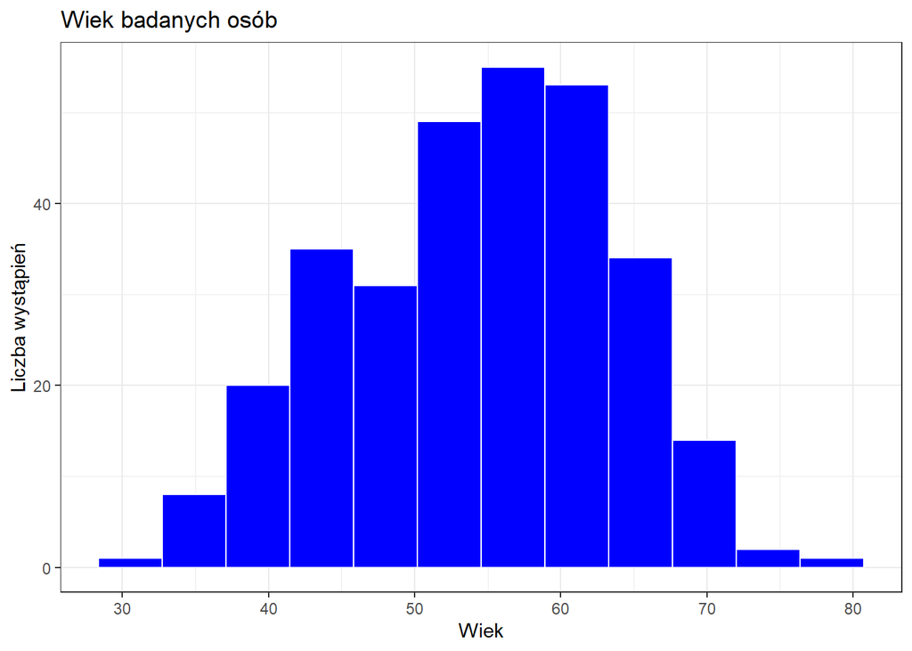

Widzimy delikatną lewostronną asymetrię, jeżeli chodzi o wiek badanych osób. Oznacza to że pacjenci są starsi.

### **Rozkład Tętna**

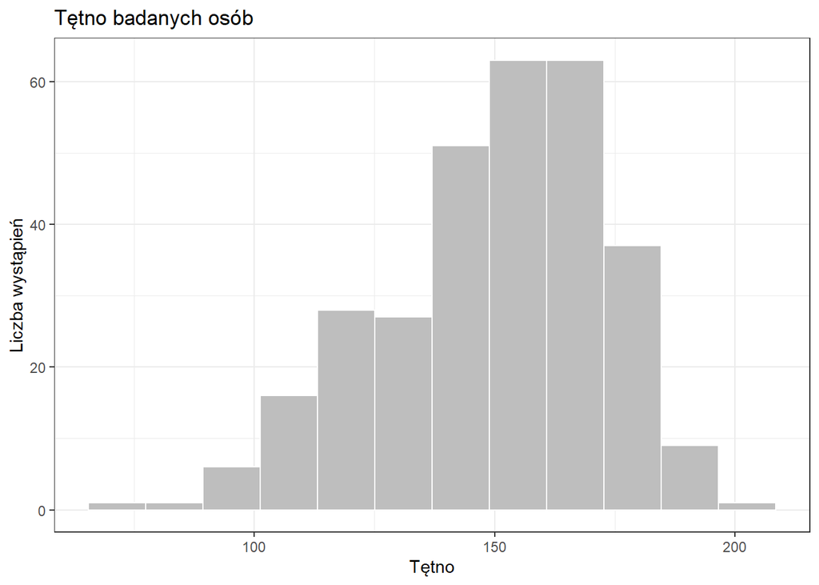

Widzimy zdecydowaną lewostronną asymetrię jeżeli chodzi o tętno badanych osób. Oznacza to, że pacjenci mają podwyższone tętno.

### **Rozkład Ciśnienia Krwi**

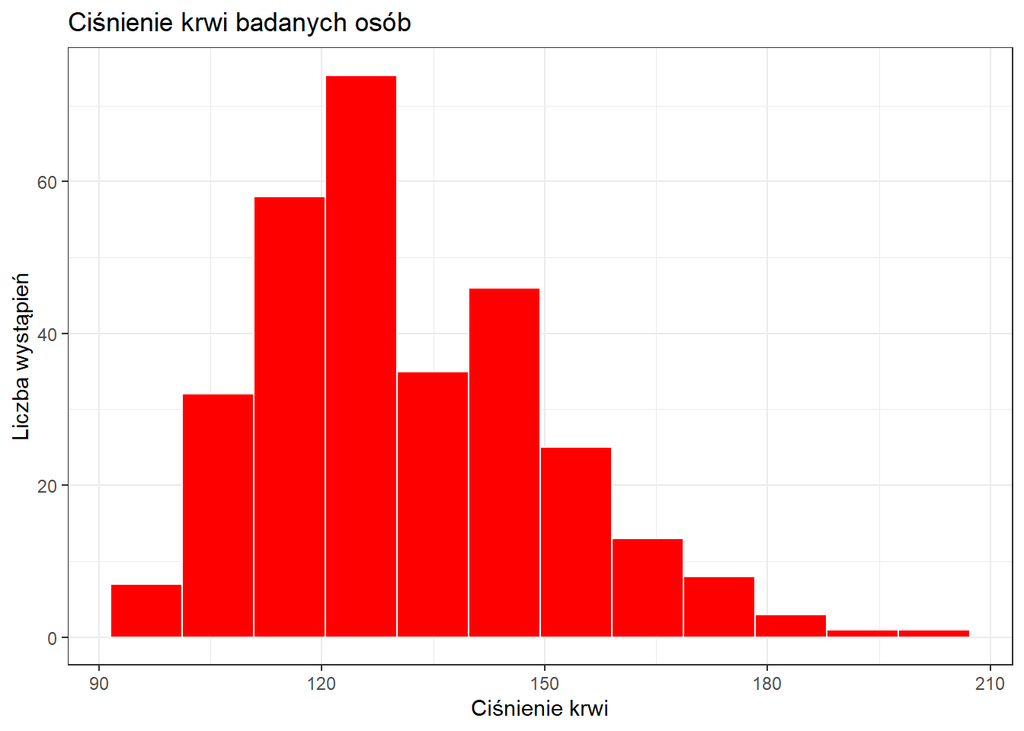

Widzimy zdecydowaną prawostronną asymetrię jeżeli chodzi o Ciśnienie krwi badanych osób. Oznacza to że pacjenci nie cechują się nadmiernie podwyższonym ciśnieniem.

### **Płeć Pacjentów**

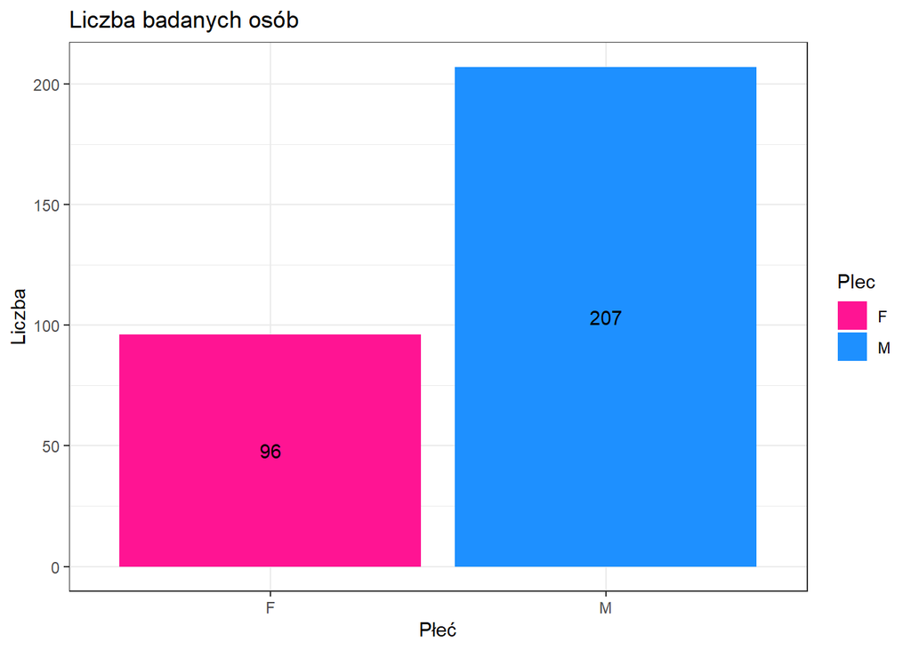

W Zbiorze danych mamy 96 kobiet oraz 207 mężczyzn, oznacza to że zbiór jest nie zbalansowany pod względem płci.

### **Poziom Cholesterolu**

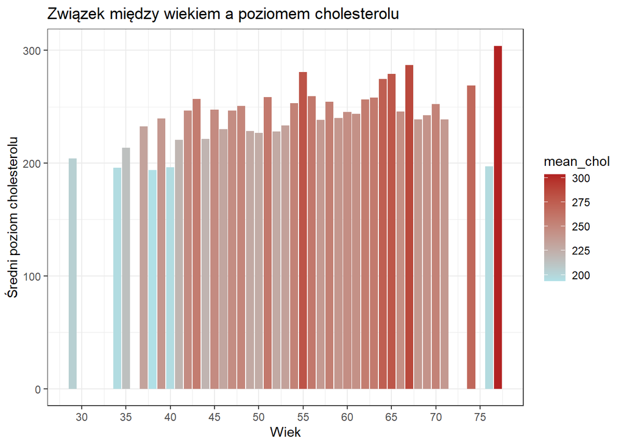

Na wykresie widzimy że wyższy poziom cholesterolu wystepuje u ludzi starszych.

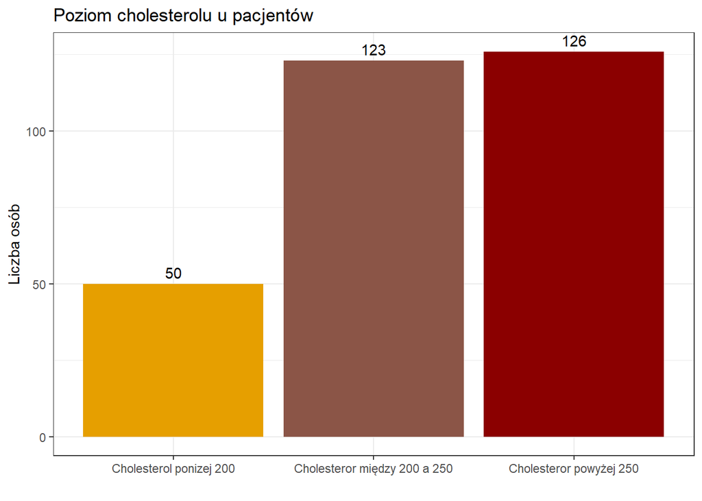

Cholesterol całkowity u zdrowego człowieka nie powinien przekraczać `200 mg/dl`. Jedynie u 50 pacjentów Cholesterol jest w normie. U 123 pacjentów Cholesterol jest na poziomie podwyższonym. 126 pacjentów ma Cholesterol znacznie podwyższony.

### **Średnia wieku**

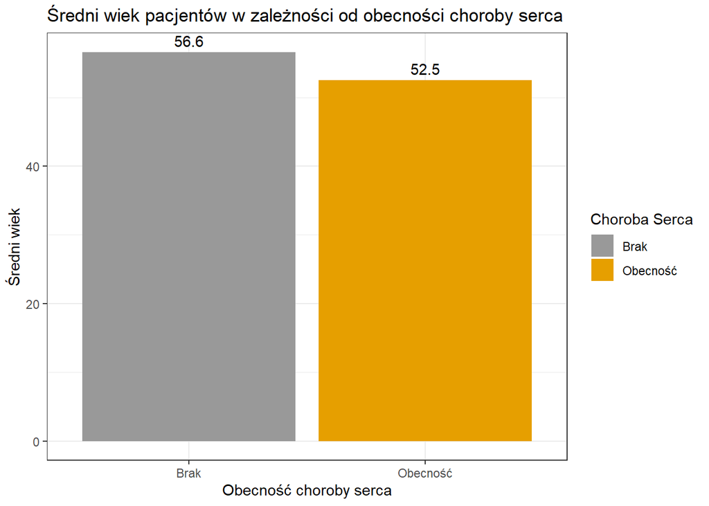

Wykres przedstawia średni wiek pacjentów w zależności od obecności choroby serca. Średni wiek pacjetnów nie posiadających choroby serca wynosi `56.6` a pacjentów posiadających chorobę serca `52.5`.

### **Typ bólu oraz Ciśnienie Krwi**

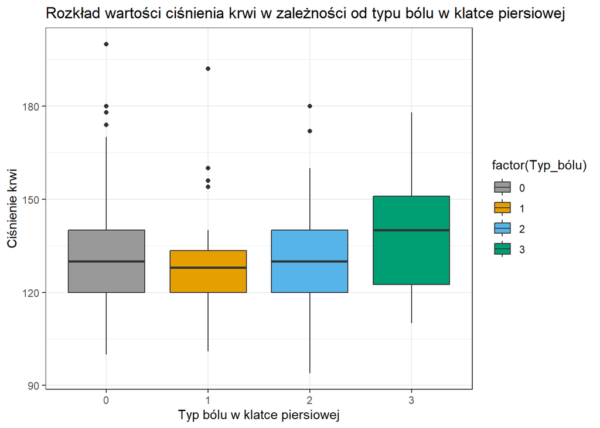

Wykres przedstawia rozkład wartości ciśnienia krwi w zależności od typu bólu w klatce piersiowej.

### **Obecność Choroby serca a tętno**

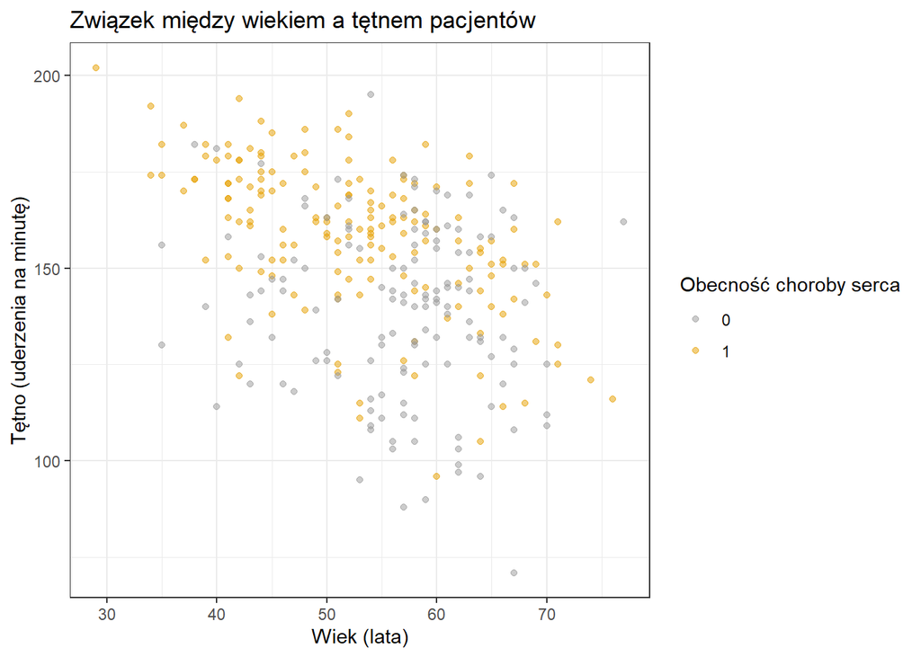

Wykres przedstawia związek między wiekiem a tętnem pacjentów, a dodatkowo oznacza, czy pacjenci mieli obecność choroby serca. Kolor punktów na wykresie odpowiada kategorii obecności choroby serca. Punkt o kolorze szarym oznacza brak choroby serca, a punkt o kolorze pomarańczowym oznacza obecność choroby serca.

## **Modelowanie**

W tym etapie przejdziemy do tworzenia modeli, które będą tworzyć predykcję odnośnie pacjentów którzy są zdrowi oraz chorzy. Modele bedą porównywane za pomocą miar `Accuracy` oraz `AUC`. Sprośród 9 modeli na końcu wybierzemy najlepszy czyli taki który ma najlepsze współczynniki dla miar czyli najlepiej przewiduje stan pacjenta.

`Accuracy` – dokładność klasyfikatora. Stosunek ilości dobrze rozpoznanych obiektów do ilości wszystkich obiektów.

Metryka oceny `AUC`(Area under Curve) jest obliczana jako obszar pod krzywą ROC (ocena poprawności klasyfikatora) i jest skalarną reprezentacją oczekiwanej wydajności klasyfikatora. Współczynnik AUC zawsze ma wartość z przedziału od 0 do 1, przy czym wyższe wartości reprezentują lepszy klasyfikator.

### **Drzewo decyzyjne**

Drzewo decyzyjne to metoda uczenia maszynowego służąca do tworzenia modeli predykcyjnych lub klasyfikacyjnych. Opiera się na hierarchicznej strukturze węzłów i krawędzi, które reprezentują decyzje i zależności między zmiennymi objaśniającymi.

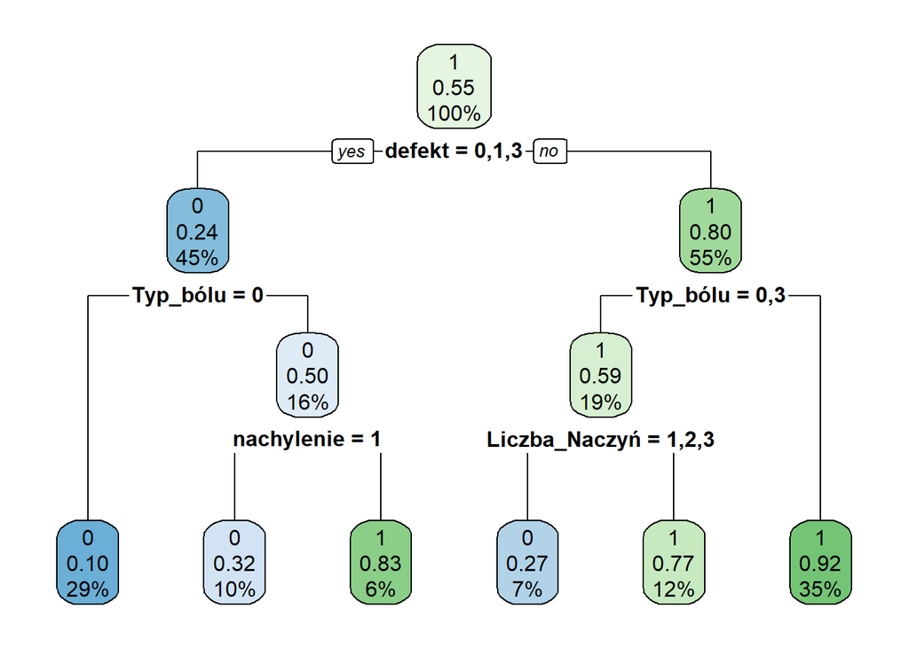

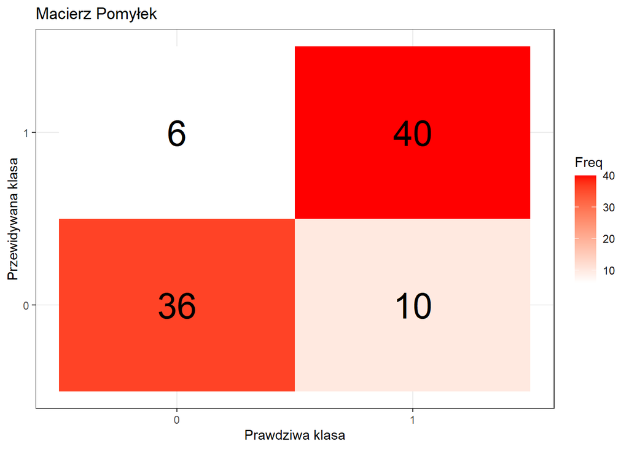

- 36 pacjentów, którzy nie chorują na chorobę serca, zostało poprawnie zidentyfikowanych jako zdrowi (wartość 0).
- 6 pacjentów, którzy nie chorują na chorobę serca, zostało błędnie zidentyfikowanych jako chorzy (wartość 1).
- 10 pacjentów, którzy chorują na chorobę serca, zostało błędnie zidentyfikowanych jako zdrowi (wartość 0).
- 40 pacjentów, którzy chorują na chorobę serca, zostało poprawnie zidentyfikowanych jako chorzy (wartość 1).

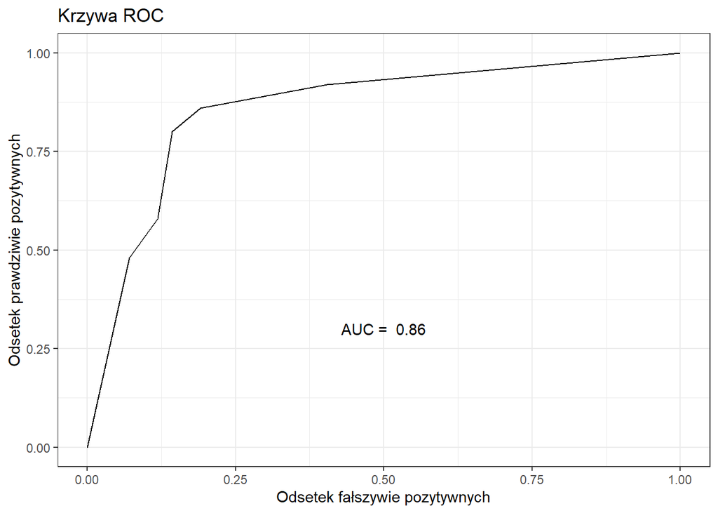

Poziom dokładności `Accuracy` wynosi: `0.83`, miara `AUC`=`0.86`.

Drzewo Decyzyjne w zadowalający sposób wykonuje klasyfikacje. Zobaczymy jak wyjdzie reszta modeli.

### **Regresja Logistyczna**

Regresja logistyczna to popularna metoda uczenia maszynowego stosowana w zadaniach klasyfikacji binarnej. Polega na szukaniu liniowej relacji między zmiennymi niezależnymi, a prawdopodobieństwem przynależności obserwacji do jednej z dwóch klas.

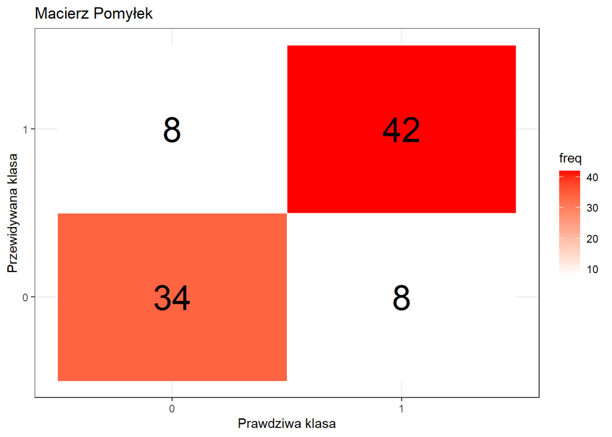

- 34 pacjentów, którzy nie chorują na chorobę serca, zostało poprawnie zidentyfikowanych jako zdrowi (wartość 0).
- 8 pacjentów, którzy nie chorują na chorobę serca, zostało błędnie zidentyfikowanych jako chorzy (wartość 1).
- 8 pacjentów, którzy chorują na chorobę serca, zostało błędnie zidentyfikowanych jako zdrowi (wartość 0).
- 42 pacjentów, którzy chorują na chorobę serca, zostało poprawnie zidentyfikowanych jako chorzy (wartość 1).

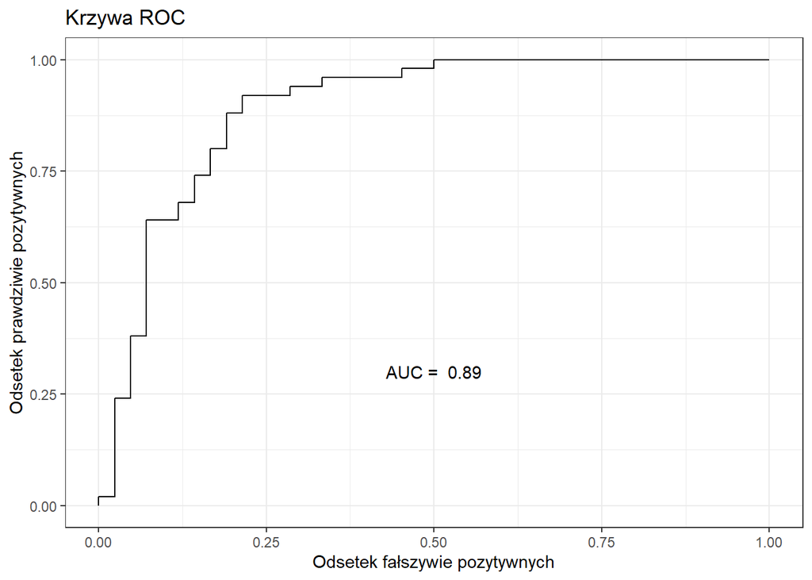

Poziom dokładności `Accuracy` wynosi `0.83`, miara `AUC`=`0.89`.

Regresja Logistyczna dała lepsze wyniki niż Drzewo Decyzyjne dlatego można podejrzewać że będzie jednym z lepszych modeli.

### **Metoda `k` najbliższych sąsiadów**

Metoda k najbliższych sąsiadów to popularna metoda uczenia maszynowego stosowana w zadaniach klasyfikacji i regresji. Algorytm polega na szukaniu k najbliższych punktów treningowych dla danej próbki testowanej i wybieraniu najczęstszej lub średniej wartości etykiet dla tych sąsiadów.

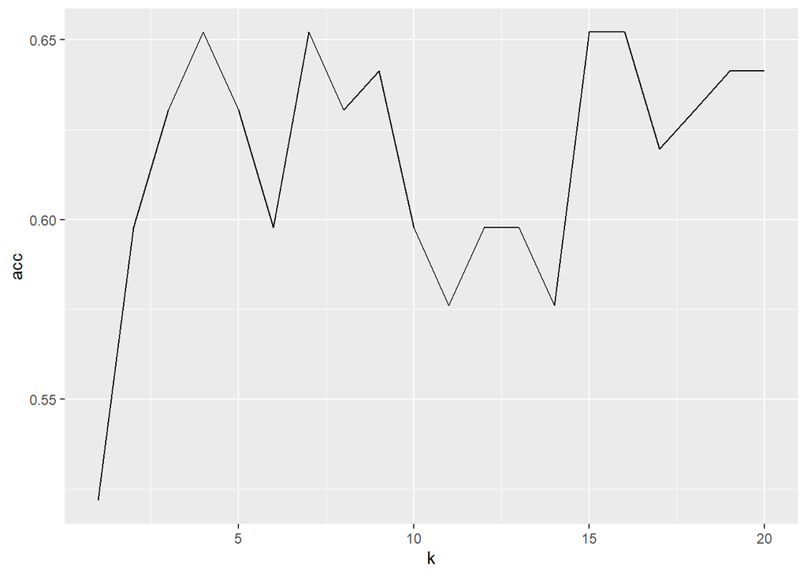

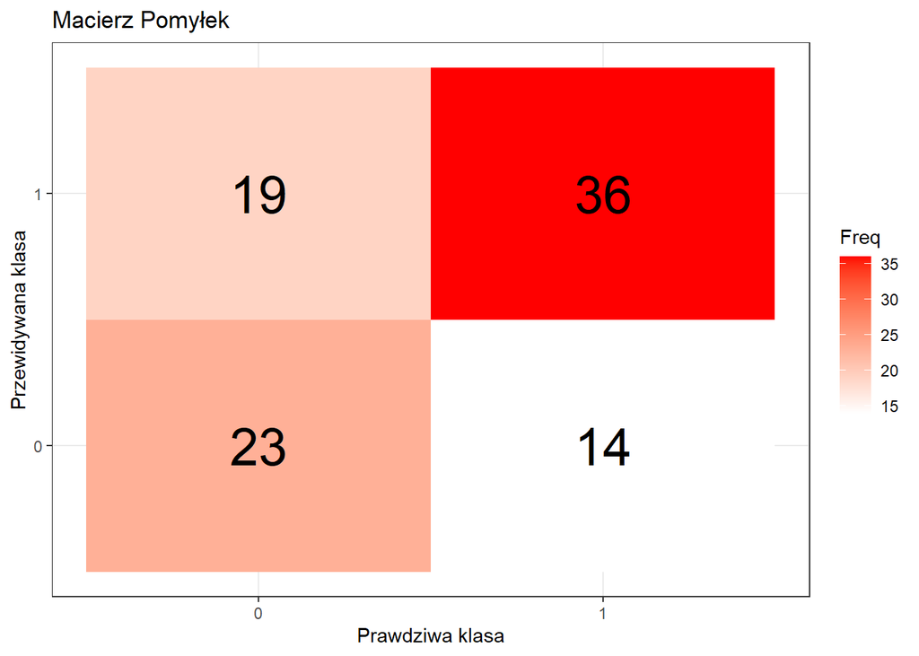

- 23 pacjentów, którzy nie chorują na chorobę serca, zostało poprawnie zidentyfikowanych jako zdrowi (wartość 0).
- 19 pacjentów, którzy nie chorują na chorobę serca, zostało błędnie zidentyfikowanych jako chorzy (wartość 1).
- 14 pacjentów, którzy chorują na chorobę serca, zostało błędnie zidentyfikowanych jako zdrowi (wartość 0).
- 36 pacjentów, którzy chorują na chorobę serca, zostało poprawnie zidentyfikowanych jako chorzy (wartość 1).

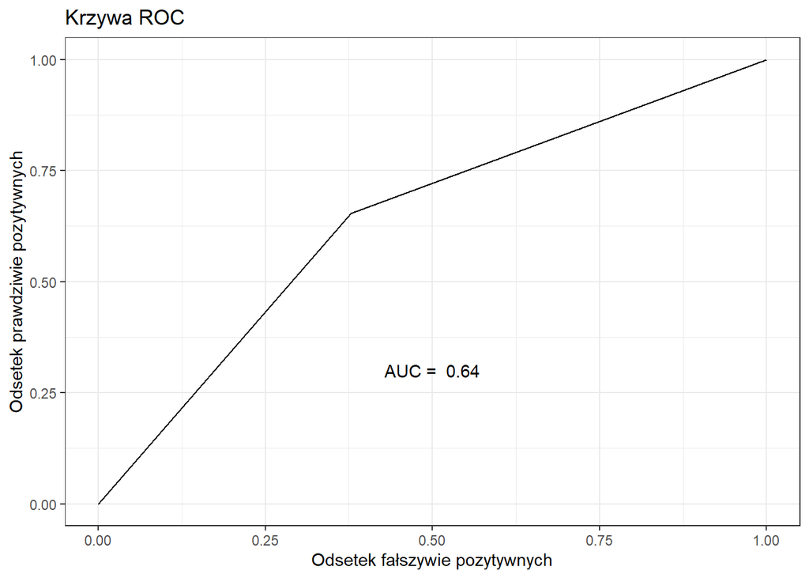

Poziom dokładności `Accuracy` wynosi `0.64`, miara `AUC`=`0.64`.

Metoda `k` najbliższych sąsiadów słabo się sprawdza w tym zadaniu, dlatego będzie to jeden z gorszych modeli.

### **Las Losowy**

Las losowy to popularny algorytm uczenia maszynowego, który polega na budowaniu wielu drzew decyzyjnych na podstawie losowych podzbiorów danych treningowych i cech. Następnie, dla każdej nowej próbki algorytm stosuje każde z drzew decyzyjnych i wybiera najczęściej pojawiającą się klasę lub średnią wartość prognozy jako wynik. Las losowy jest wydajny i ma wysoką skuteczność w klasyfikacji i regresji, a także może być stosowany do redukcji wymiarowości i wykrywania ważnych cech danych.

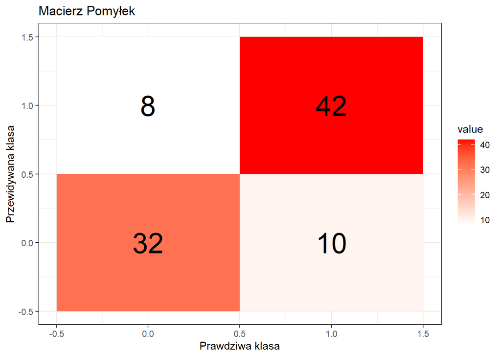

- 32 pacjentów, którzy nie chorują na chorobę serca, zostało poprawnie zidentyfikowanych jako zdrowi (wartość 0).
- 8 pacjentów, którzy nie chorują na chorobę serca, zostało błędnie zidentyfikowanych jako chorzy (wartość 1).
- 10 pacjentów, którzy chorują na chorobę serca, zostało błędnie zidentyfikowanych jako zdrowi (wartość 0).
- 42 pacjentów, którzy chorują na chorobę serca, zostało poprawnie zidentyfikowanych jako chorzy (wartość 1).

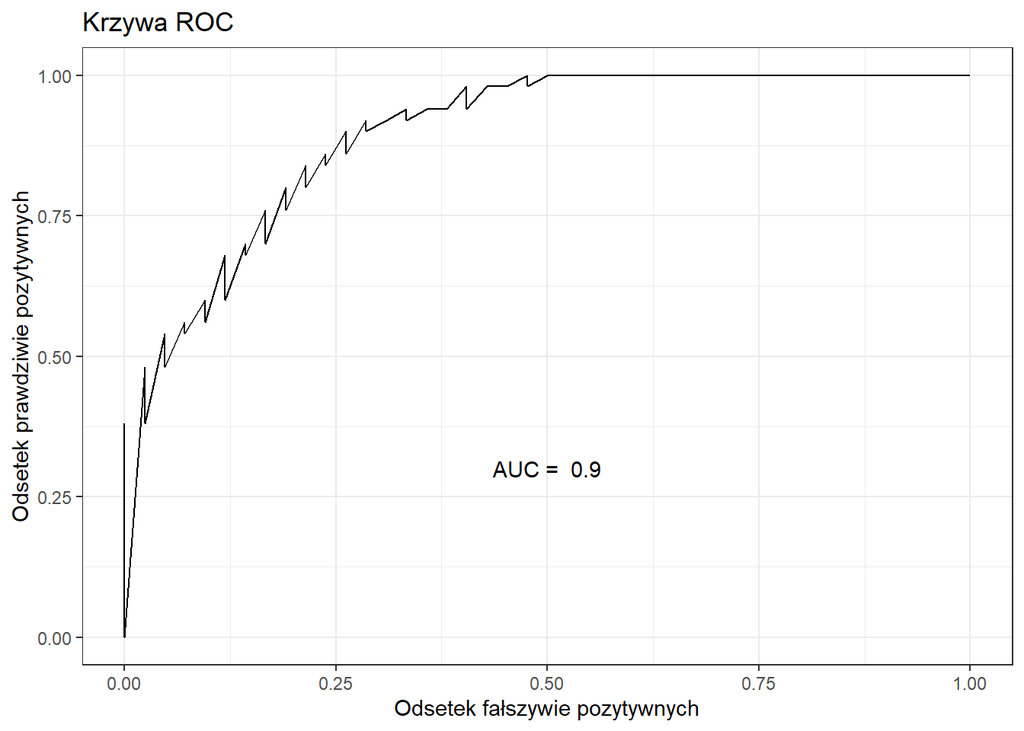

Poziom dokładności `Accuracy` wynosi `0.8`, miara `AUC`=`0.9`.

Las Losowy nie podał lepszych wyników niż Regresja Logistyczna.

### **Klasyfikator Bayesowski**

Klasyfikator bayesowski to algorytm uczenia maszynowego, który opiera się na twierdzeniu Bayesa $P \left(A|B\right)=\frac{P\left(B|A\right)\cdot P \left(A\right)}{P \left(B \right)}$ i służy do przewidywania przynależności obiektu do jednej z kilku klas na podstawie cech obiektu. Wykorzystuje wiedzę a priori o danych oraz prawdopodobieństwa warunkowe, aby dokonać klasyfikacji.

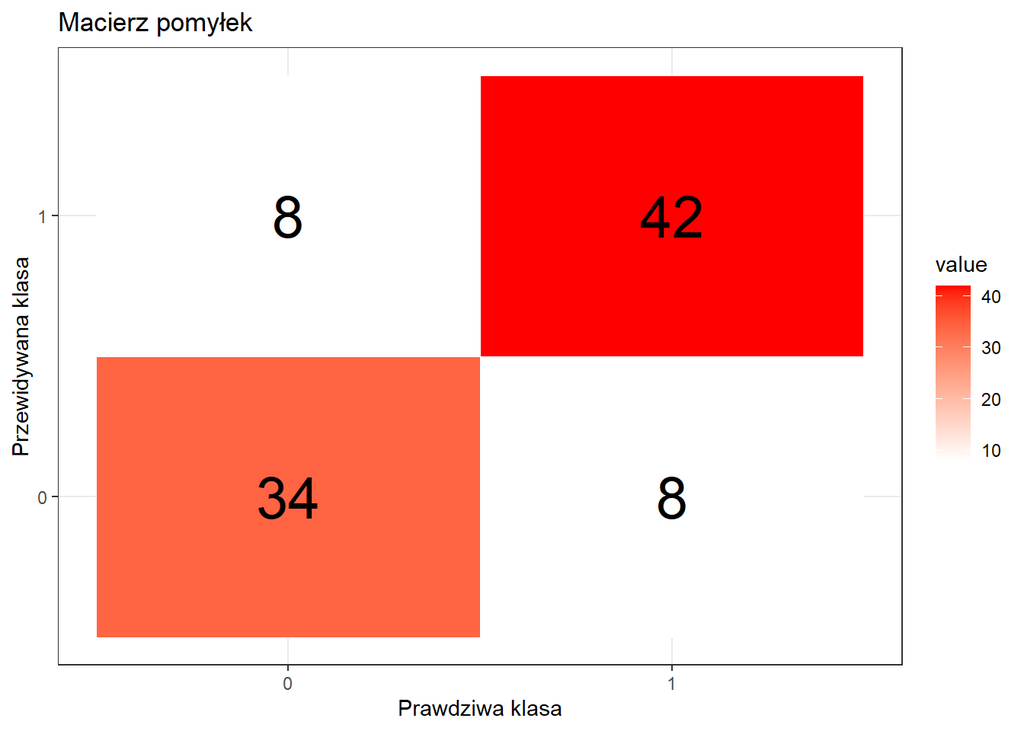

- 34 pacjentów, którzy nie chorują na chorobę serca, zostało poprawnie zidentyfikowanych jako zdrowi (wartość 0).
- 8 pacjentów, którzy nie chorują na chorobę serca, zostało błędnie zidentyfikowanych jako chorzy (wartość 1).
- 8 pacjentów, którzy chorują na chorobę serca, zostało błędnie zidentyfikowanych jako zdrowi (wartość 0).
- 42 pacjentów, którzy chorują na chorobę serca, zostało poprawnie zidentyfikowanych jako chorzy (wartość 1).

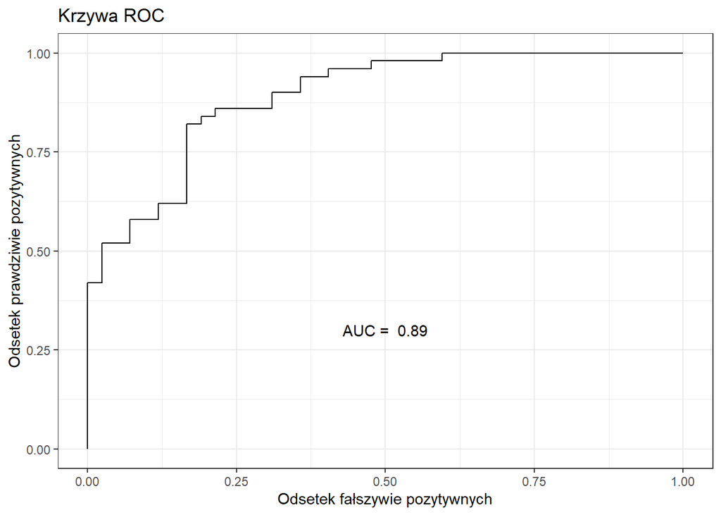

Klasyfikator Bayesowski możemy zaliczyć do średniej jakości modeli w kontekście tego zadania.

### **Liniowa Analiza Dyskryminatywna**

Liniowa analiza dyskryminacyjna (ang. Linear Discriminant Analysis, LDA) to metoda statystyczna stosowana do analizy i klasyfikacji danych. Metoda ta służy do znajdowania liniowych kombinacji zmiennych objaśniających, które najlepiej oddzielają różne grupy danych.

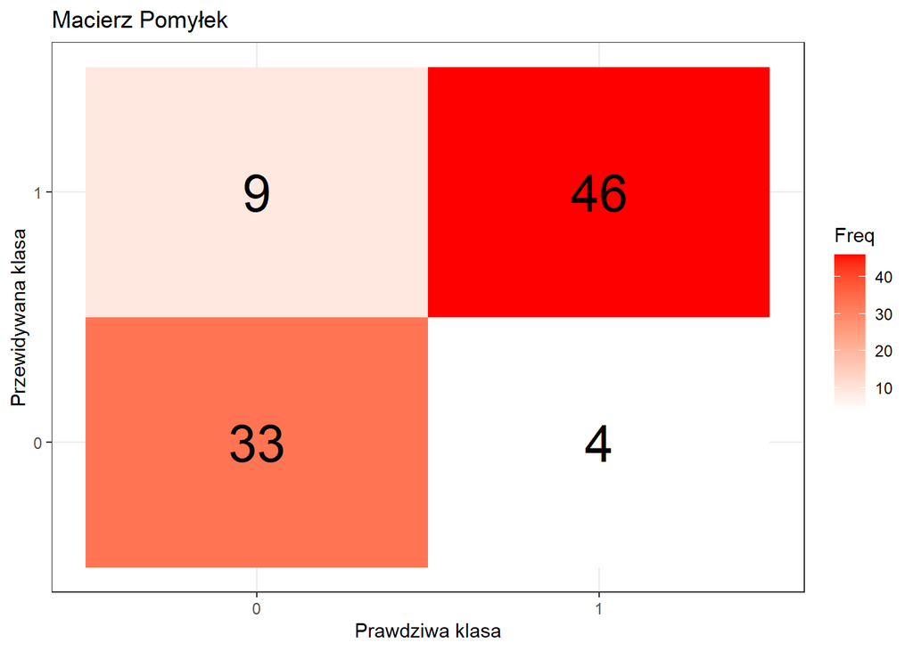

- 33 pacjentów, którzy nie chorują na chorobę serca, zostało poprawnie zidentyfikowanych jako zdrowi (wartość 0).
- 9 pacjentów, którzy nie chorują na chorobę serca, zostało błędnie zidentyfikowanych jako chorzy (wartość 1).
- 4 pacjentów, którzy chorują na chorobę serca, zostało błędnie zidentyfikowanych jako zdrowi (wartość 0).
- 46 pacjentów, którzy chorują na chorobę serca, zostało poprawnie zidentyfikowanych jako chorzy (wartość 1).

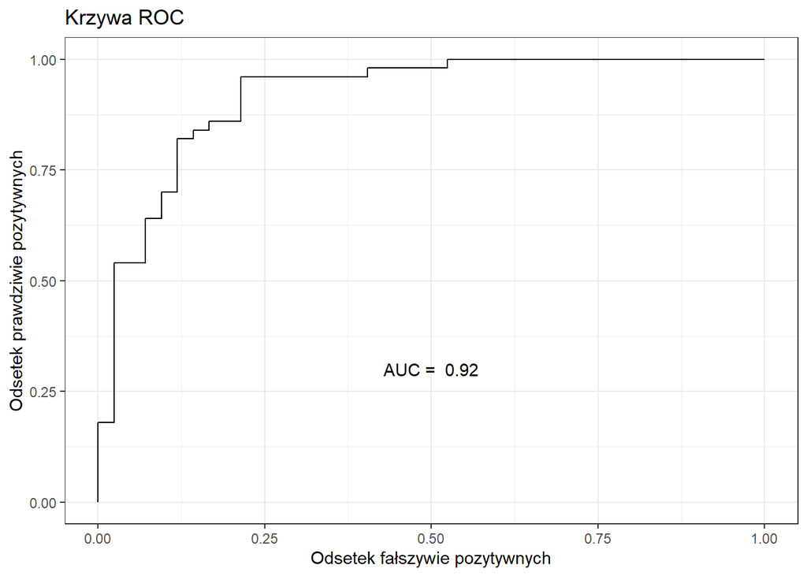

Poziom dokładności `Accuracy` wynosi `0.86`, miara `AUC`=`0.92`.

Liniowa Analiza Dyskryminatywna dała lepsze wyniki niż Las Losowy dlatego, z dostępnych modeli naraźie jest najlepszym.

### **Metoda wektorów nośnych**

SVM to metoda klasyfikacji i regresji, która opiera się na wyznaczeniu hiperpłaszczyzny rozdzielającej dane o różnych klasach lub wartościach docelowych. SVM dąży do maksymalizacji odległości między hiperpłaszczyzną a najbliższymi punktami z każdej klasy. Dzięki temu SVM dobrze radzi sobie z problemami, gdzie istnieją nieliniowe zależności między zmiennymi.

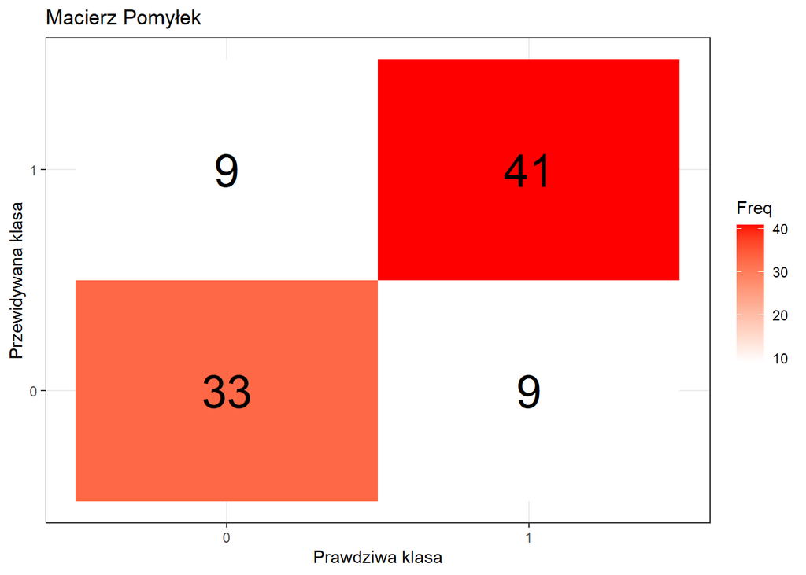

- 33 pacjentów, którzy nie chorują na chorobę serca, zostało poprawnie zidentyfikowanych jako zdrowi (wartość 0).
- 9 pacjentów, którzy nie chorują na chorobę serca, zostało błędnie zidentyfikowanych jako chorzy (wartość 1).
- 9 pacjentów, którzy chorują na chorobę serca, zostało błędnie zidentyfikowanych jako zdrowi (wartość 0).
- 41 pacjentów, którzy chorują na chorobę serca, zostało poprawnie zidentyfikowanych jako chorzy (wartość 1).

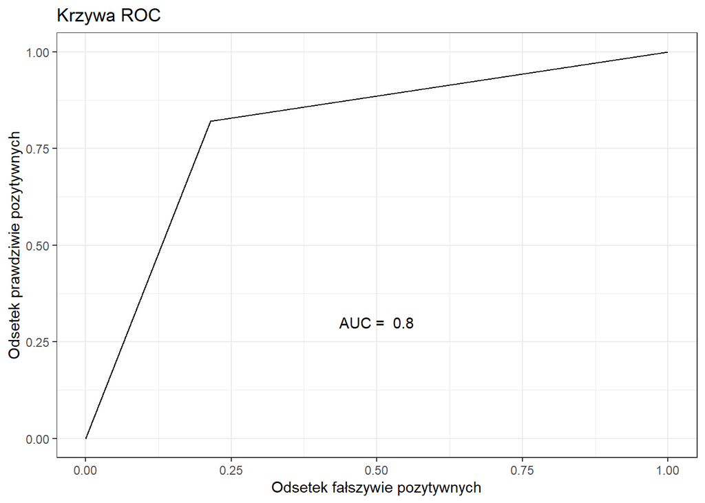

Poziom dokładności `Accuracy` wynosi `0.8`, miara `AUC`=`0.8`.

Metoda Wektorów Nośnych dała średnie wyniki.

### **Wzmocnienie Gradientu**

Wzmocnienie Gradientu jest metodą zespołową, która łączy wiele słabych modeli w celu stworzenia silnego klasyfikatora. Popularne implementacje to XGBoost, LightGBM i CatBoost.

|  | Wpływ |
| --- | --- |
| defekt | 17.678 |
| Liczba_Naczyń | 14.145 |
| Tętno | 12.576 |
| Wiek | 11.705 |
| Typ_bólu | 10.260 |
| spadek_odcinka_ST | 8.285 |
| Cholesterol | 7.148 |
| nachylenie | 5.278 |
| Ciśnienie_krwi | 5.159 |
| Dławica_Piersiowa | 4.723 |
| Wynik_EKG | 1.858 |
| Plec | 1.185 |
| Cukier | 0.000 |

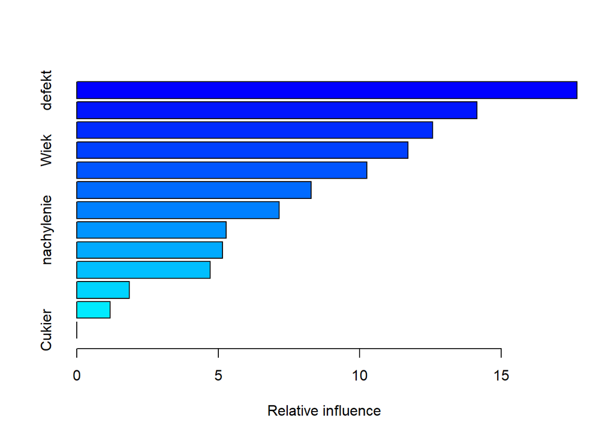

Z powyższego wykresu oraz tabeli widzimy że najmocniejszy wpływ na Chorobe Serce mają zmienne: `defekt`, `Liczba Naczyń`, `Tętno`, `Wiek` oraz `Typ bólu`.

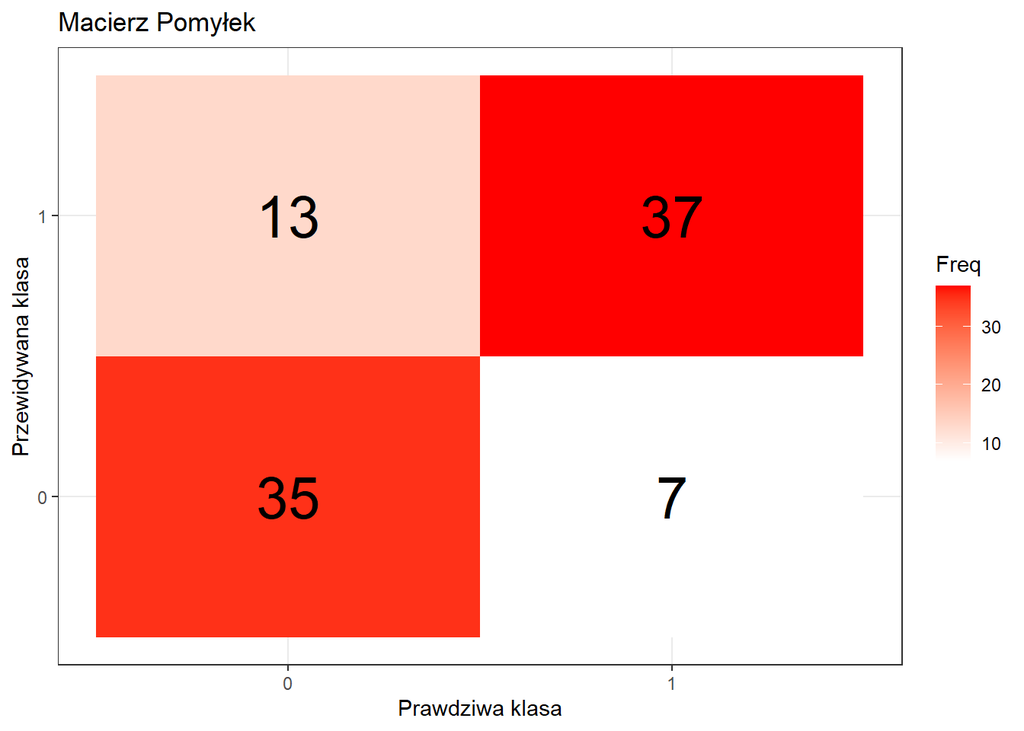

- 35 pacjentów, którzy nie chorują na chorobę serca, zostało poprawnie zidentyfikowanych jako zdrowi (wartość 0).
- 13 pacjentów, którzy nie chorują na chorobę serca, zostało błędnie zidentyfikowanych jako chorzy (wartość 1).
- 7 pacjentów, którzy chorują na chorobę serca, zostało błędnie zidentyfikowanych jako zdrowi (wartość 0).
- 37 pacjentów, którzy chorują na chorobę serca, zostało poprawnie zidentyfikowanych jako chorzy (wartość 1).

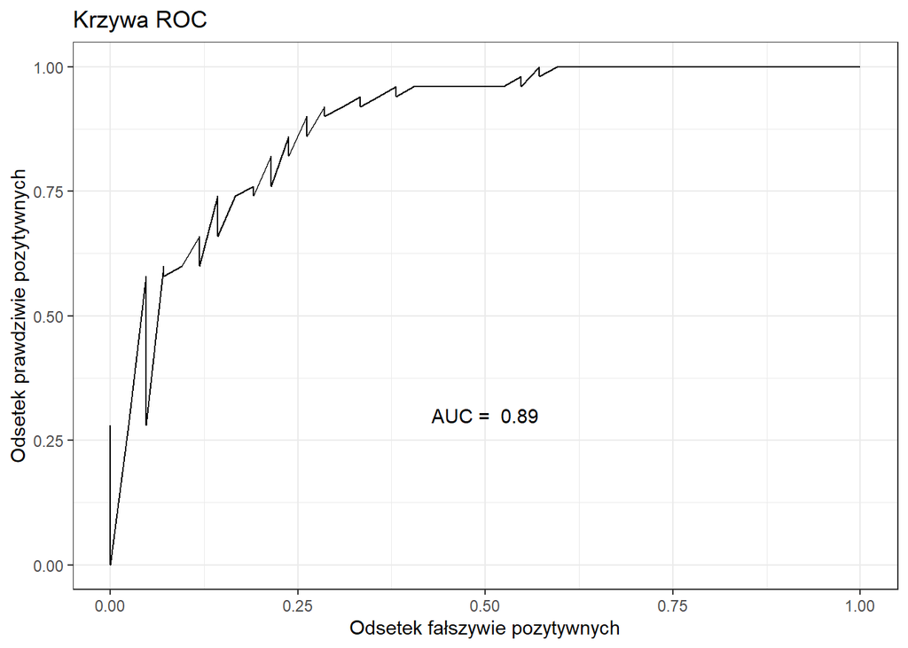

Poziom dokładności `Accuracy` wynosi `0.78`, miara `AUC`=`0.89`.

Wzmocnienie Gradientu dało średnie wyniki.

### **Sieć Neuronowa**

Sieć neuronowa to model matematyczny, który składa się z połączonych ze sobą neuronów. Sieć neuronowa otrzymuje sygnały wejściowe, wykonuje pewne obliczenia i przesyła sygnał wyjściowy do innych neuronów. Sieci neuronowe są stosowane w wielu dziedzinach, w tym w rozpoznawaniu obrazów, rozpoznawaniu mowy, klasyfikacji danych i przewidywaniu wyników.

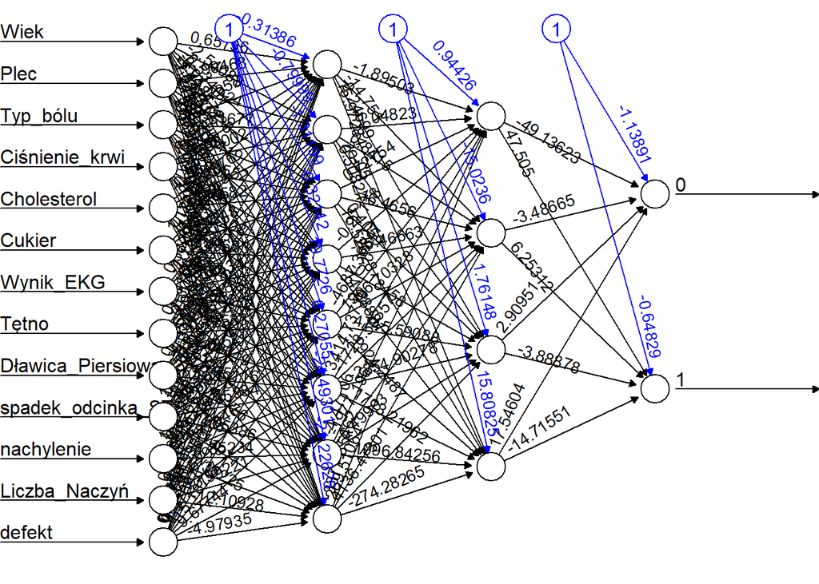

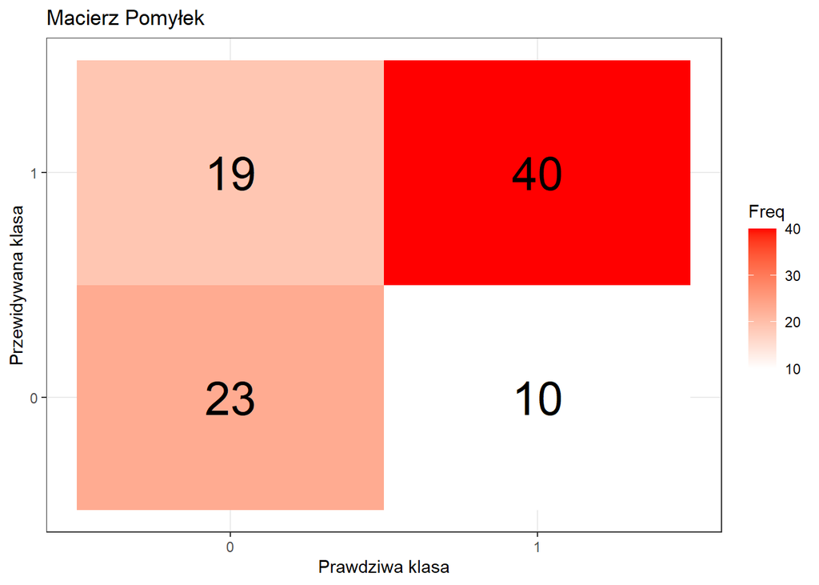

- 23 pacjentów, którzy nie chorują na chorobę serca, zostało poprawnie zidentyfikowanych jako zdrowi (wartość 0).
- 19 pacjentów, którzy nie chorują na chorobę serca, zostało błędnie zidentyfikowanych jako chorzy (wartość 1).
- 10 pacjentów, którzy chorują na chorobę serca, zostało błędnie zidentyfikowanych jako zdrowi (wartość 0).
- 40 pacjentów, którzy chorują na chorobę serca, zostało poprawnie zidentyfikowanych jako chorzy (wartość 1).

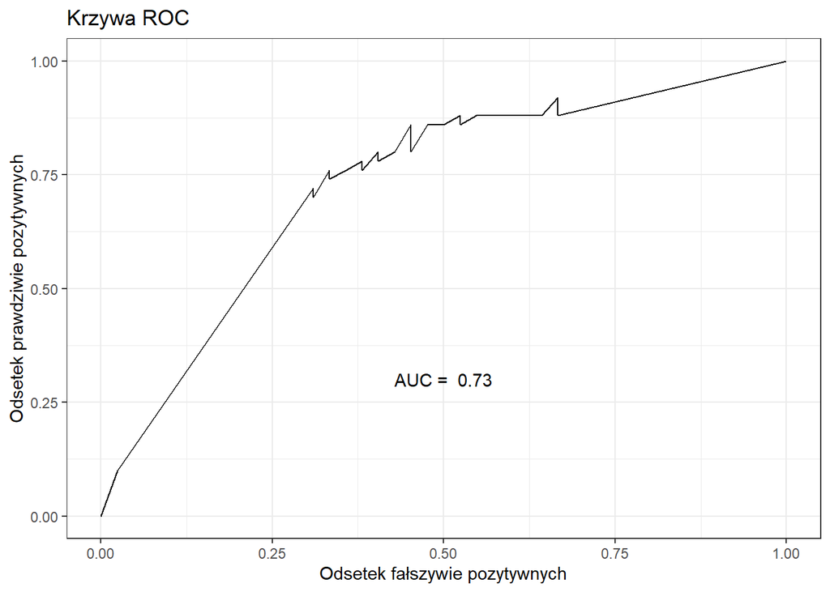

Poziom dokładności `Accuracy` wynosi `0.68`, miara `AUC`=`0.73`.

Śieć Neuronowa dała średnie wyniki.

## **Podsumowanie i Wnioski**

Z wcześniej utworzonych modeli wybierzemy najlepszy. Możemy to zrobić porównując ze sobą metryki `Accuracy` oraz `AUC`.

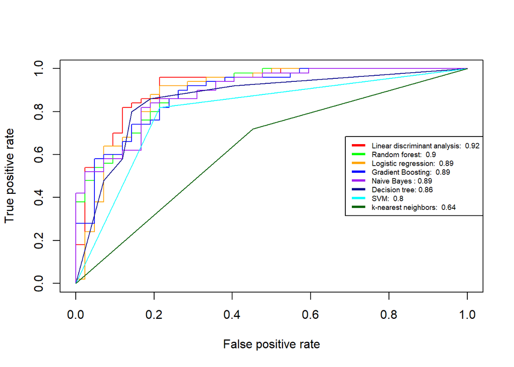

Z powyższego wykresu widzimy że większa ilość wykresów `ROC` się zlewa natomiast można wyróżnić najlepszy którym jest Liniowa Analiza Dyskryminatywna oraz najgorszy którym jest metoda `k` najbliższych sąsiadów.

[output not shown]

Po przeprowadzeniu analizy danych oraz modelowaniu za pomocą dziewięciu modeli, możemy uznać, że modelem najlepiej radzącym sobie z klasyfikacją pacjentów ze względu na wystąpienie `Choroby Serca`, jest model Liniowej Analizy Dyskryminacyjnej. Osiągną on wyniki, `Accuracy`=0.86 oraz `AUC`=0.92. Podczas klasyfikacji pomylił się jedynie trzynaście razy, na dziewięćdziesiąt dwa możliwych przypadków.

## **Bibliografia**

1. `https://dax44.github.io/datamining/`

2.`https://dax44.github.io/ModelsValidation/?fbclid=IwAR3VjEcYyvIyIBX31M9Tf2Wsiz4sSkFrvKsnzqkZb2cMh_iRVZlNmuTwBNQ`